# Short-term effects of air pollution on mortality in Milan

2026-02-09

## Introduction

This report presents an exploratory analysis of daily mortality and air pollution data for the city of Milan, Italy, covering a period of ten consecutive years from **January 1, 1980 to December 30, 1989** (3,652 days).

The dataset includes daily measurements of total mortality, meteorological variables, and air pollution indicators, in particular **sulfur dioxide (SO₂)** and **total suspended particulates (TSP)**. Calendar-related covariates such as **day of the week** and **public holidays** are also available, allowing adjustment for short-term temporal patterns.

The main objective of this analysis is to explore the short-term association between air pollution and mortality. The analysis focuses on data cleaning, variable transformation, exploratory visualization, and descriptive statistics, which form the basis for subsequent modeling.

The data were originally analyzed in:

> Vigotti, M.A., Rossi, G., Bisanti, L., Zanobetti, A., and Schwartz, J. (1996). *Short term effect of urban air pollution on respiratory health in Milan, Italy, 1980–1989*. **Journal of Epidemiology and Community Health**, 50, S71–S75.

The dataset is also documented in:

> Ruppert, D., Wand, M.P., and Carroll, R.J. (2003). *Semiparametric Regression*. Cambridge University Press.

## 1. Libraries and data loading

```r
library(dplyr)
library(lubridate)
library(ggplot2)
library(lme4)
library(performance)
library(MASS)
```

```r
filePath <- "C:/Users/mavip/Desktop"
setwd(filePath)

df <- read.table("mil.txt", header = TRUE, sep = "")
```

```r
count(df)
```

```
##      n
## 1 3652
```

```r
str(df)
```

```
## 'data.frame':    3652 obs. of  9 variables:
##  $ day.num    : int  1 2 3 4 5 6 7 8 9 10 ...
##  $ day.of.week: int  2 3 4 5 6 7 1 2 3 4 ...
##  $ holiday    : int  1 0 0 0 0 0 0 0 0 0 ...
##  $ mean.temp  : num  5.6 4.1 4.6 2.9 2.2 0.7 -0.6 -0.5 0.2 1.7 ...
##  $ rel.humid  : num  30 26 29.7 32.7 71.3 80.7 82 82.7 79.3 69.3 ...
##  $ tot.mort   : num  45 32 37 33 36 45 46 38 29 39 ...
##  $ resp.mort  : int  2 5 0 1 1 6 2 4 1 4 ...
##  $ SO2        : num  267 375 276 440 354 ...
##  $ TSP        : num  110 153 162 198 235 ...
```

```r
head(df)
```

```
##   day.num day.of.week holiday mean.temp rel.humid tot.mort resp.mort    SO2
## 1       1           2       1       5.6      30.0       45         2 267.33
## 2       2           3       0       4.1      26.0       32         5 374.98
## 3       3           4       0       4.6      29.7       37         0 276.25
## 4       4           5       0       2.9      32.7       33         1 440.50
## 5       5           6       0       2.2      71.3       36         1 354.25
## 6       6           7       0       0.7      80.7       45         6 334.50
##      TSP
## 1 109.56
## 2 152.68
## 3 162.16
## 4 197.52
## 5 234.59
## 6 167.34
```

```r
tail(df)
```

```
##      day.num day.of.week holiday mean.temp rel.humid tot.mort resp.mort    SO2
## 3647    3647           1       1       3.9      93.0       38         5  57.75
## 3648    3648           2       1       3.7      91.3       37         2  56.00
## 3649    3649           3       0       4.0      83.3       37         3  67.75
## 3650    3650           4       0       1.2      89.0       32         2 113.00
## 3651    3651           5       0      -1.0      95.0       42         3 133.25
## 3652    3652           6       0      -2.0      95.0       31         4 133.75
##         TSP
## 3647  64.53
## 3648  77.47
## 3649  93.85
## 3650 100.75
## 3651  72.29
## 3652  83.50
```

## 2. Recoding of categorical variables

```r
df$day.of.week <- factor(
  df$day.of.week,
  levels = 1:7,
  labels = c("Mon", "Tue", "Wed", "Thu", "Fri", "Sat", "Sun")
)

df$holiday <- factor(
  df$holiday,
  levels = 0:1,
  labels = c("No holiday", "Holiday")
)
```

## 3. Data cleaning

```r
df <- df %>% filter(SO2 > 0, TSP > 0)
```

```r
df <- df %>%
  mutate(
    date  = as.Date(day.num, origin = "1980-01-01"),
    year  = year(date),
    month = month(date),
    season = factor(
      case_when(
        month %in% 3:5  ~ "Spring",
        month %in% 6:8  ~ "Summer",
        month %in% 9:11 ~ "Autumn",
        TRUE            ~ "Winter"
      ),
      levels = c("Winter", "Spring", "Summer", "Autumn")
    ),
    log_SO2 = signif(log(SO2), digits = 5),
    log_TSP = signif(log(TSP), digits = 5)
  )
```

```r
count(df)
```

```
##      n
## 1 3646
```

```r
head(df)
```

```
##   day.num day.of.week    holiday mean.temp rel.humid tot.mort resp.mort    SO2
## 1       1         Tue    Holiday       5.6      30.0       45         2 267.33
## 2       2         Wed No holiday       4.1      26.0       32         5 374.98
## 3       3         Thu No holiday       4.6      29.7       37         0 276.25
## 4       4         Fri No holiday       2.9      32.7       33         1 440.50
## 5       5         Sat No holiday       2.2      71.3       36         1 354.25
## 6       6         Sun No holiday       0.7      80.7       45         6 334.50
##      TSP       date year month season log_SO2 log_TSP
## 1 109.56 1980-01-02 1980     1 Winter  5.5885  4.6965
## 2 152.68 1980-01-03 1980     1 Winter  5.9269  5.0283
## 3 162.16 1980-01-04 1980     1 Winter  5.6213  5.0886
## 4 197.52 1980-01-05 1980     1 Winter  6.0879  5.2858
## 5 234.59 1980-01-06 1980     1 Winter  5.8700  5.4578
## 6 167.34 1980-01-07 1980     1 Winter  5.8126  5.1200
```

```r
table(df$season)
```

```
##
## Winter Spring Summer Autumn
##    902    915    919    910
```

```r
summary(df$log_SO2)
```

```
##    Min. 1st Qu.  Median    Mean 3rd Qu.    Max.
##  -4.605   3.474   4.174   4.237   5.063   6.719
```

```r
summary(df$log_TSP)
```

```
##    Min. 1st Qu.  Median    Mean 3rd Qu.    Max.
##   1.253   4.426   4.765   4.772   5.139   6.272
```

## 4. Outlier analysis

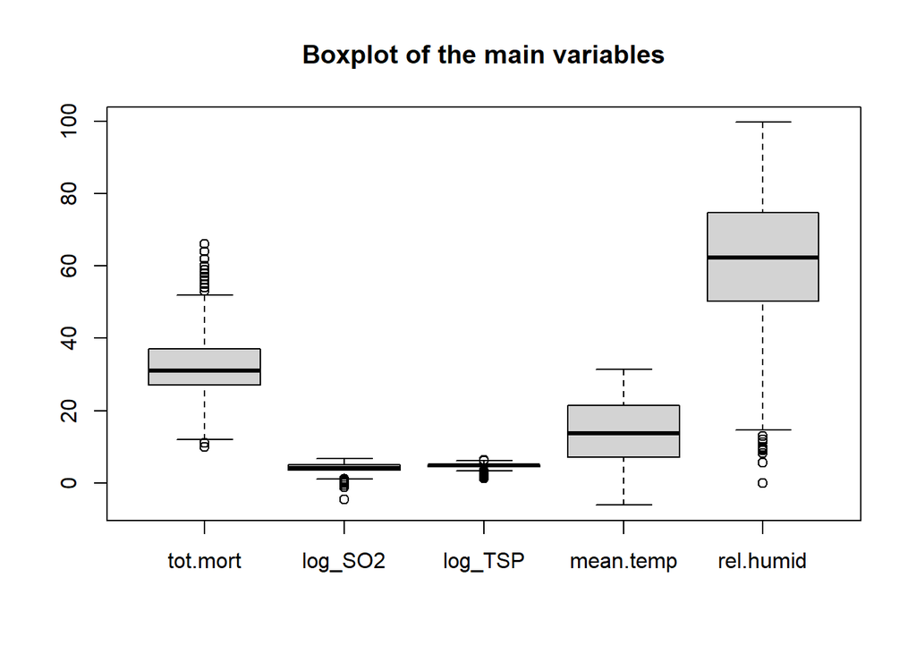

```r
boxplot(df[, c("tot.mort", "log_SO2", "log_TSP", "mean.temp", "rel.humid")],
        main = "Boxplot of the main variables")
```

## 5. Exploratory relationships

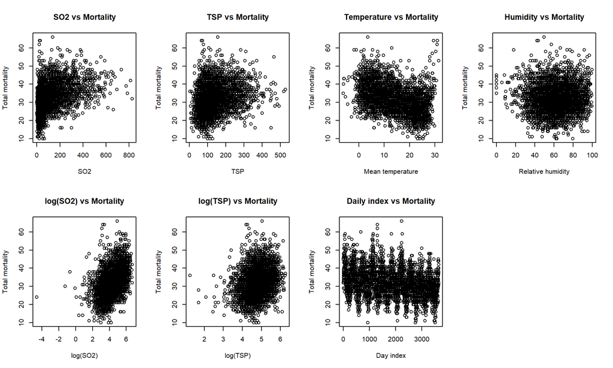

```r
par(mfrow = c(2,4))

# With pollutants there seems to be a slight correlation
plot(df$SO2, df$tot.mort, main = "SO2 vs Mortality",
     xlab = "SO2", ylab = "Total mortality")

# With pollutants there seems to be a slight correlation
plot(df$TSP, df$tot.mort, main = "TSP vs Mortality",
     xlab = "TSP", ylab = "Total mortality")

# Temperature–mortality shows a U/J-shaped relationship
plot(df$mean.temp, df$tot.mort, main = "Temperature vs Mortality",
     xlab = "Mean temperature", ylab = "Total mortality")

plot(df$rel.humid, df$tot.mort, main = "Humidity vs Mortality",
     xlab = "Relative humidity", ylab = "Total mortality")

# With pollutants there seems to be a slight correlation
plot(df$log_SO2, df$tot.mort, main = "log(SO2) vs Mortality",
     xlab = "log(SO2)", ylab = "Total mortality")

# With pollutants there seems to be a slight correlation
plot(df$log_TSP, df$tot.mort, main = "log(TSP) vs Mortality",
     xlab = "log(TSP)", ylab = "Total mortality")

# There are evident annual cycles in mortality
plot(df$day.num, df$tot.mort, main = "Daily index vs Mortality",
     xlab = "Day index", ylab = "Total mortality")

par(mfrow = c(1,1))
```

## 6. Descriptive statistics

```r
glimpse(df)
```

```
## Rows: 3,646
## Columns: 15
## $ day.num     <int> 1, 2, 3, 4, 5, 6, 7, 8, 9, 10, 11, 12, 13, 14, 15, 16, 17,…
## $ day.of.week <fct> Tue, Wed, Thu, Fri, Sat, Sun, Mon, Tue, Wed, Thu, Fri, Sat…
## $ holiday     <fct> Holiday, No holiday, No holiday, No holiday, No holiday, N…
## $ mean.temp   <dbl> 5.6, 4.1, 4.6, 2.9, 2.2, 0.7, -0.6, -0.5, 0.2, 1.7, 2.7, 0…
## $ rel.humid   <dbl> 30.0, 26.0, 29.7, 32.7, 71.3, 80.7, 82.0, 82.7, 79.3, 69.3…
## $ tot.mort    <dbl> 45, 32, 37, 33, 36, 45, 46, 38, 29, 39, 36, 35, 34, 48, 36…
## $ resp.mort   <int> 2, 5, 0, 1, 1, 6, 2, 4, 1, 4, 2, 4, 3, 5, 5, 3, 3, 3, 3, 5…
## $ SO2         <dbl> 267.33, 374.98, 276.25, 440.50, 354.25, 334.50, 619.50, 56…
## $ TSP         <dbl> 109.56, 152.68, 162.16, 197.52, 234.59, 167.34, 216.49, 23…
## $ date        <date> 1980-01-02, 1980-01-03, 1980-01-04, 1980-01-05, 1980-01-0…
## $ year        <dbl> 1980, 1980, 1980, 1980, 1980, 1980, 1980, 1980, 1980, 1980…
## $ month       <dbl> 1, 1, 1, 1, 1, 1, 1, 1, 1, 1, 1, 1, 1, 1, 1, 1, 1, 1, 1, 1…
## $ season      <fct> Winter, Winter, Winter, Winter, Winter, Winter, Winter, Wi…
## $ log_SO2     <dbl> 5.5885, 5.9269, 5.6213, 6.0879, 5.8700, 5.8126, 6.4289, 6.…
## $ log_TSP     <dbl> 4.6965, 5.0283, 5.0886, 5.2858, 5.4578, 5.1200, 5.3775, 5.…
```

```r
summary(df[, c("tot.mort", "SO2", "TSP", "mean.temp", "rel.humid")])
```

```
##     tot.mort          SO2              TSP           mean.temp
##  Min.   :10.00   Min.   :  0.01   Min.   :  3.50   Min.   :-6.10
##  1st Qu.:27.00   1st Qu.: 32.26   1st Qu.: 83.58   1st Qu.: 7.10
##  Median :31.00   Median : 65.00   Median :117.28   Median :13.70
##  Mean   :31.87   Mean   :114.94   Mean   :136.54   Mean   :14.03
##  3rd Qu.:37.00   3rd Qu.:158.03   3rd Qu.:170.50   3rd Qu.:21.40
##  Max.   :66.00   Max.   :827.75   Max.   :529.50   Max.   :31.50
##    rel.humid
##  Min.   : 0.00
##  1st Qu.:50.30
##  Median :62.30
##  Mean   :62.04
##  3rd Qu.:74.70
##  Max.   :99.70
```

**Observations from the exploratory relationships:**

- **Temperature – Mortality**: A clear U- or J-shaped relationship is observed, with higher mortality at both very low and very high temperatures. This suggests that both extreme cold and extreme heat increase the risk of mortality.
- **Pollutants (SO2 and TSP) – Mortality**: A slight positive correlation is observed between pollutant levels and mortality. The association appears more evident when using logarithmic transformations of the pollutants.

## 7. Exploratory plots (ggplot2)

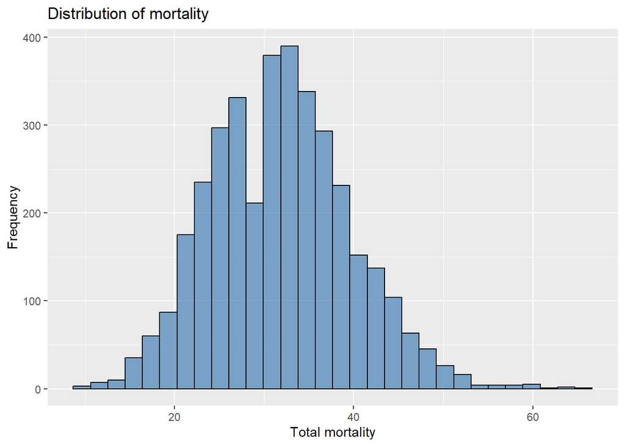

```r
p1 <- ggplot(df, aes(x = tot.mort)) +
  geom_histogram(bins = 30, fill = "steelblue", alpha = 0.7, color = "black") +
  labs(title = "Distribution of mortality",
       x = "Total mortality",
       y = "Frequency")

p2 <- ggplot(df, aes(x = day.num, y = tot.mort)) +
  geom_line(alpha = 0.5) +
  geom_smooth(color = "red", se = FALSE) +
  labs(title = "",
       x = "Day",
       y = "Total mortality")

p1
```

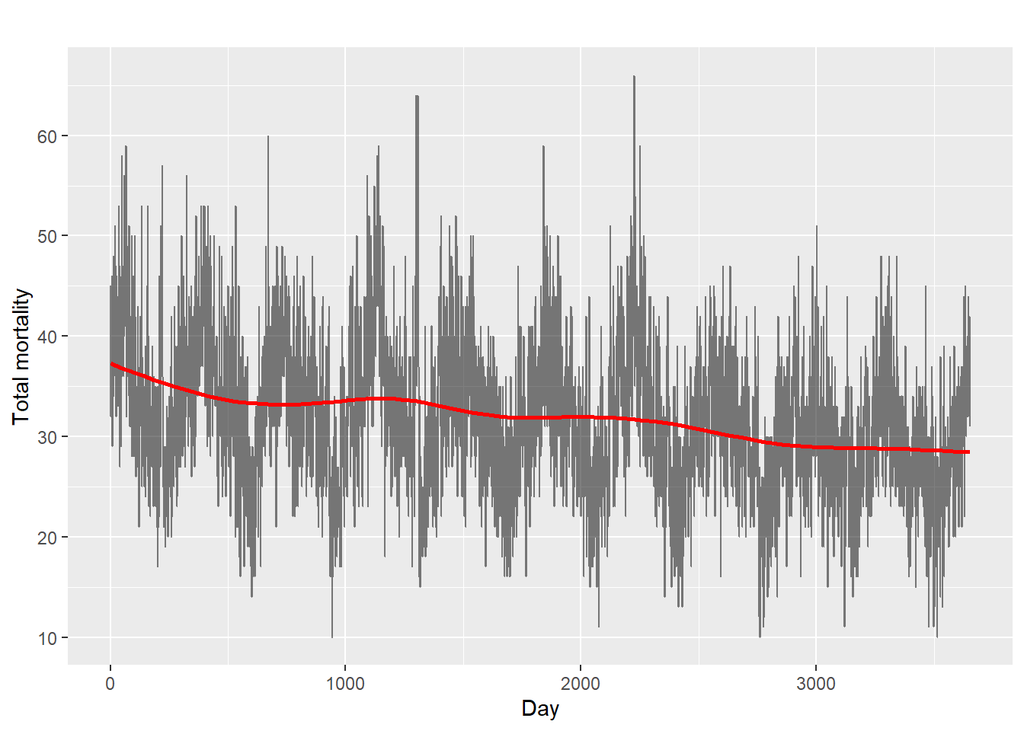

```r
p2
```

**Note**: The plot clearly highlights the annual cycles in mortality, with recurring peaks likely associated with winter months and adverse climatic conditions.

## 8. Saving the cleaned dataset

```r
write.table(df, "df_clean.txt", sep = " ", row.names = FALSE, quote = FALSE)
print("Cleaned dataset saved as 'df_clean.txt'")
```

```
## [1] "Cleaned dataset saved as 'df_clean.txt'"
```